# Projekt I Przetwarzanie danych środowiskowych: Wybrane metody regresyjne w analizie danych.

Krzysztof Kusztykiewicz WGGIŚ Geoinformacja rok II

09 czerwiec, 2022

# 1. Cel projektu

| Celem projektu jest zastosowanie wybranych metod regresyjnych do analizy wybranego zestawu danych, stworzenie modeli predykcyjnych oraz ich ocena. |
| --- |

# 2. Zestaw danych

## 2.1 Pozyskanie danych

[output not shown]

## 2.2 Zestaw danych

Zestaw danych *Concrate_Data.xls* zawiera następujące kolumny:

```
## # A tibble: 6 × 9
##   cement zuzel_wp popiol_lot  woda super_plast krusz_grub krusz_drob  wiek wytrz
##    <dbl>    <dbl>      <dbl> <dbl>       <dbl>      <dbl>      <dbl> <dbl> <dbl>
## 1   540        0           0   162         2.5      1040        676     28  80.0
## 2   540        0           0   162         2.5      1055        676     28  61.9
## 3   332.     142.          0   228         0         932        594    270  40.3
## 4   332.     142.          0   228         0         932        594    365  41.1
## 5   199.     132.          0   192         0         978.       826.   360  44.3
## 6   266      114           0   228         0         932        670     90  47.0
```

W prowadzonych analizach będziemy rozważać zależność **wytrzymałości betonu** od poszczególnych składników. Warto zwrócić uwagę, że występuje także kolumna “wiek”.

# 3. Analiza danych

## 3.1 Przegląd predyktorów

Rozkład poszczególnych predyktorów w zależności od badanej obserwacji:

```r
summary(dt)
```

```
##      cement         zuzel_wp       popiol_lot          woda
##  Min.   :102.0   Min.   :  0.0   Min.   :  0.00   Min.   :121.8
##  1st Qu.:192.4   1st Qu.:  0.0   1st Qu.:  0.00   1st Qu.:164.9
##  Median :272.9   Median : 22.0   Median :  0.00   Median :185.0
##  Mean   :281.2   Mean   : 73.9   Mean   : 54.19   Mean   :181.6
##  3rd Qu.:350.0   3rd Qu.:142.9   3rd Qu.:118.27   3rd Qu.:192.0
##  Max.   :540.0   Max.   :359.4   Max.   :200.10   Max.   :247.0
##   super_plast       krusz_grub       krusz_drob         wiek
##  Min.   : 0.000   Min.   : 801.0   Min.   :594.0   Min.   :  1.00
##  1st Qu.: 0.000   1st Qu.: 932.0   1st Qu.:731.0   1st Qu.:  7.00
##  Median : 6.350   Median : 968.0   Median :779.5   Median : 28.00
##  Mean   : 6.203   Mean   : 972.9   Mean   :773.6   Mean   : 45.66
##  3rd Qu.:10.160   3rd Qu.:1029.4   3rd Qu.:824.0   3rd Qu.: 56.00
##  Max.   :32.200   Max.   :1145.0   Max.   :992.6   Max.   :365.00
##      wytrz
##  Min.   : 2.332
##  1st Qu.:23.707
##  Median :34.443
##  Mean   :35.818
##  3rd Qu.:46.136
##  Max.   :82.599
```

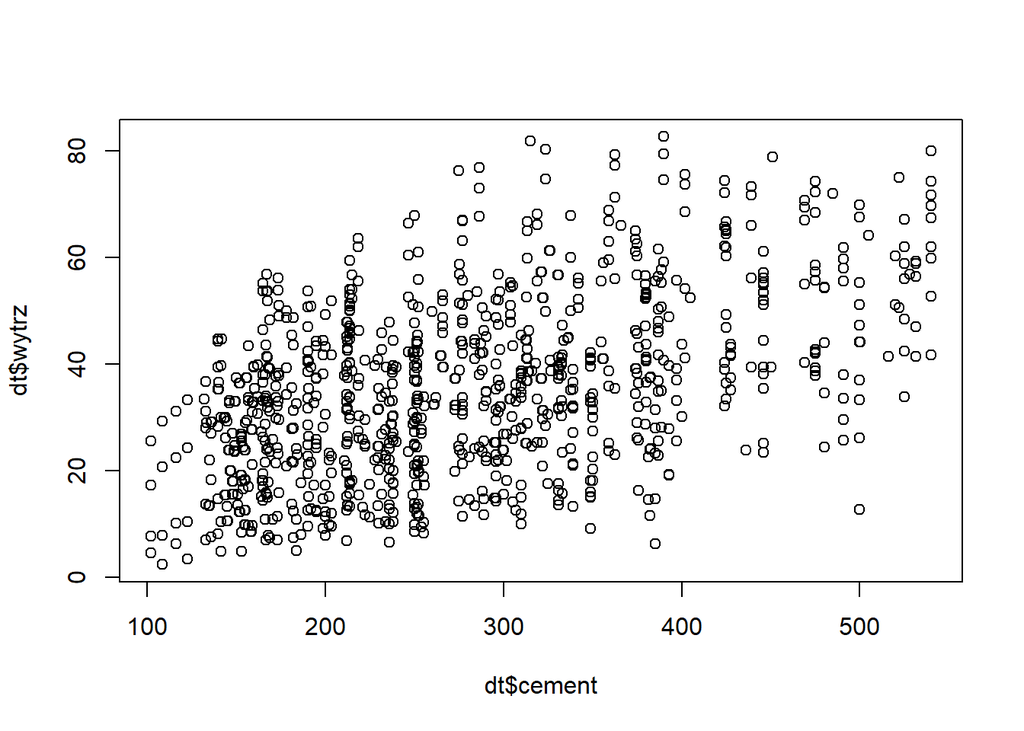

```r
plot(dt$cement, dt$wytrz)
```

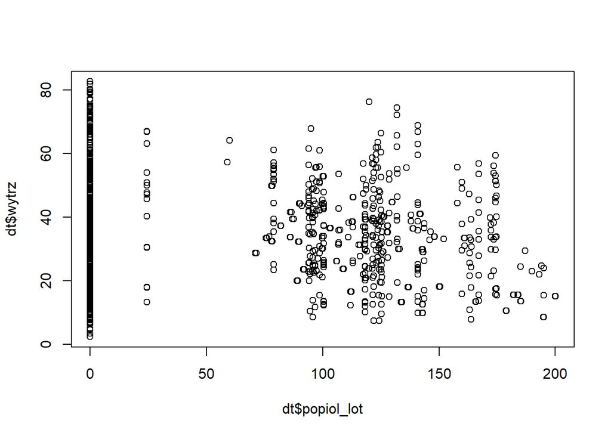

```r
plot(dt$popiol_lot, dt$wytrz)
```

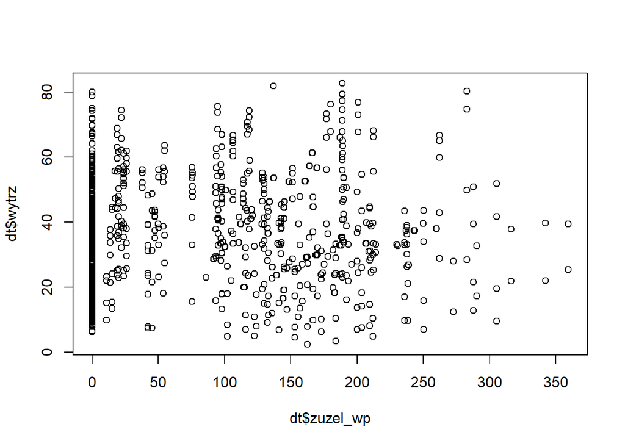

```r
plot(dt$zuzel_wp,dt$wytrz)
```

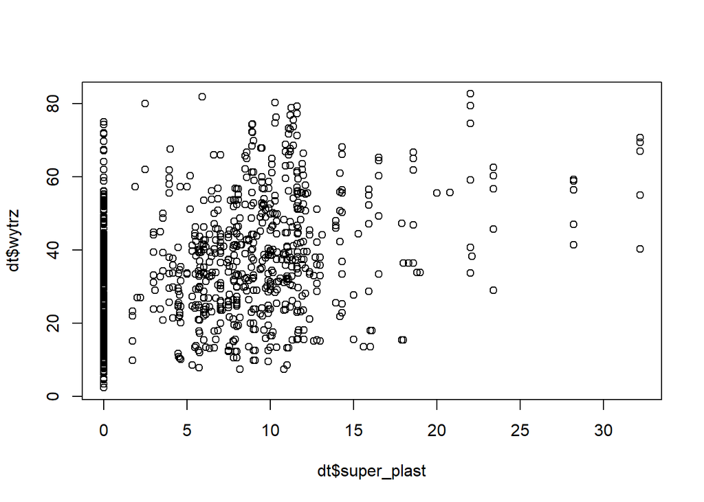

```r
plot(dt$super_plast, dt$wytrz)
```

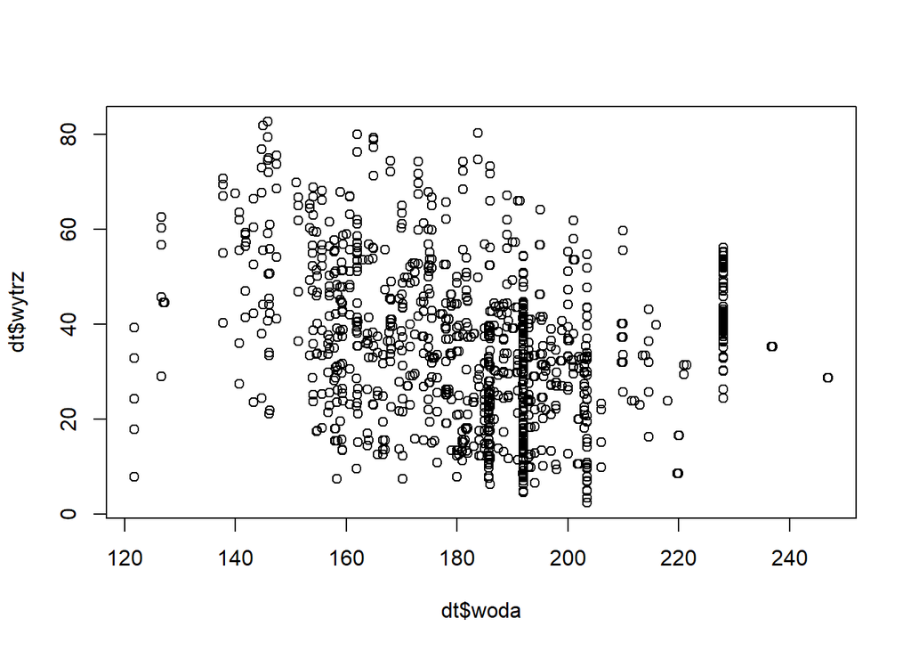

```r
plot(dt$woda, dt$wytrz)
```

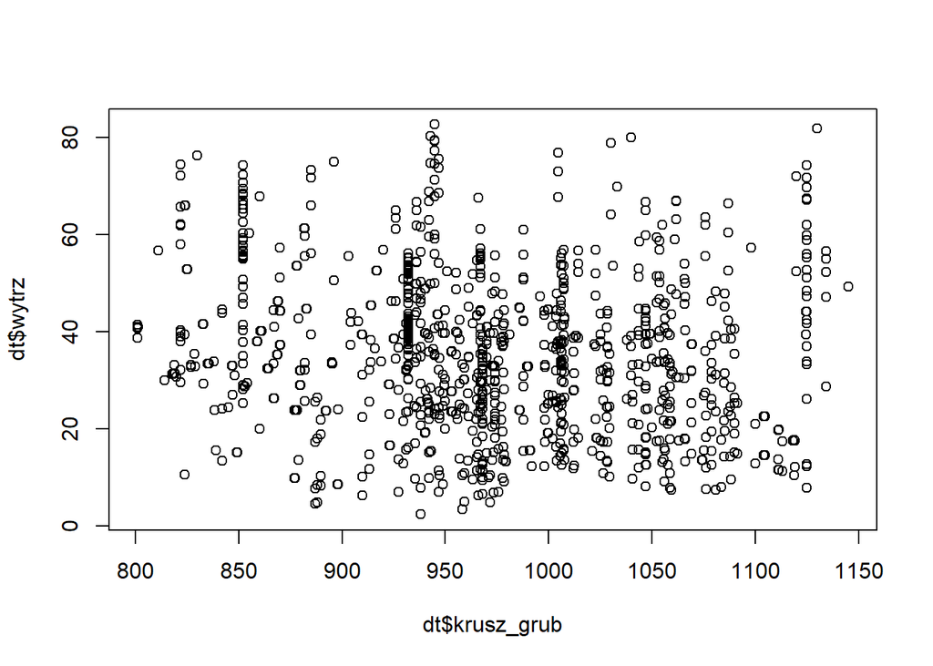

```r
plot(dt$krusz_grub, dt$wytrz)
```

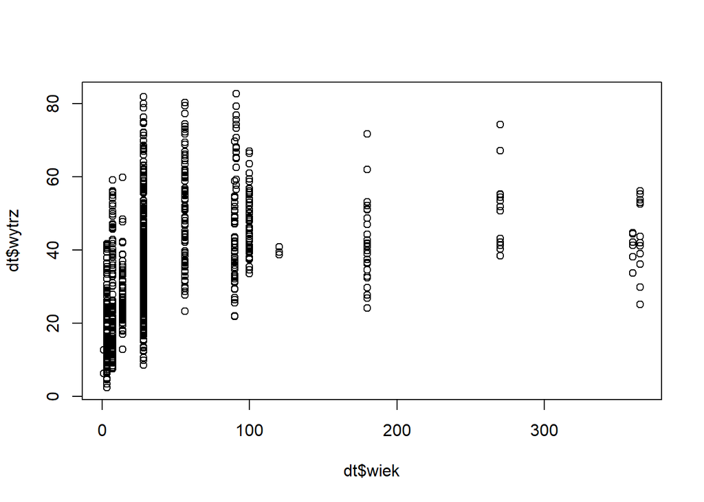

```r
plot(dt$wiek, dt$wytrz) #nieliniowa zaleznosc
```

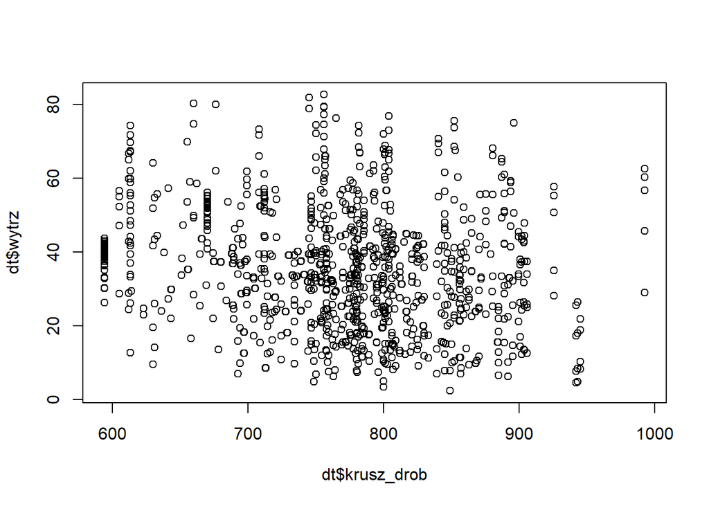

```r
plot(dt$krusz_drob, dt$wytrz)
```

Można zauważyć, że wartości są znacząco rozproszone. Przy niektórych predyktorach może pojawić się problem nieliniowości. Początkowo widać, że zależność wytrzymałości od wieku na pewno nie jest liniowa.

## 3.3 Pierwsze modele

Początkowo zostały stworzone trzy modele: m1 - model regresji prostej (jako predyktor został wybrany cement, ponieważ wykres ich zależności wygląda obiecująco); m2 - model regresji wielorakiej z uwzględnieniem wszystkich czynników; m3 - model regresji wielorakiej z interakcjami.

Można przyjrzeć się współczynnikom np. dla modelu m2 oraz m3

```r
m1<-lm(data = dt, formula = wytrz~cement)
m2<-lm(data = dt, formula = wytrz~.)
m3 <-lm(data = dt, formula = wytrz~.*.)
summary(m1)
```

```
##
## Call:
## lm(formula = wytrz ~ cement, data = dt)
##
## Residuals:
##     Min      1Q  Median      3Q     Max
## -40.594 -10.952  -0.572   9.992  43.241
##
## Coefficients:
##              Estimate Std. Error t value Pr(>|t|)
## (Intercept) 13.442795   1.296925   10.37   <2e-16 ***
## cement       0.079580   0.004324   18.41   <2e-16 ***
## ---
## Signif. codes:  0 '***' 0.001 '**' 0.01 '*' 0.05 '.' 0.1 ' ' 1
##
## Residual standard error: 14.5 on 1028 degrees of freedom
## Multiple R-squared:  0.2478, Adjusted R-squared:  0.2471
## F-statistic: 338.7 on 1 and 1028 DF,  p-value: < 2.2e-16
```

```r
summary(m2)
```

```
##
## Call:
## lm(formula = wytrz ~ ., data = dt)
##
## Residuals:
##     Min      1Q  Median      3Q     Max
## -28.653  -6.303   0.704   6.562  34.446
##
## Coefficients:
##               Estimate Std. Error t value Pr(>|t|)
## (Intercept) -23.163756  26.588421  -0.871 0.383851
## cement        0.119785   0.008489  14.110  < 2e-16 ***
## zuzel_wp      0.103847   0.010136  10.245  < 2e-16 ***
## popiol_lot    0.087943   0.012585   6.988 5.03e-12 ***
## woda         -0.150298   0.040179  -3.741 0.000194 ***
## super_plast   0.290687   0.093460   3.110 0.001921 **
## krusz_grub    0.018030   0.009394   1.919 0.055227 .
## krusz_drob    0.020154   0.010703   1.883 0.059968 .
## wiek          0.114226   0.005427  21.046  < 2e-16 ***
## ---
## Signif. codes:  0 '***' 0.001 '**' 0.01 '*' 0.05 '.' 0.1 ' ' 1
##
## Residual standard error: 10.4 on 1021 degrees of freedom
## Multiple R-squared:  0.6155, Adjusted R-squared:  0.6125
## F-statistic: 204.3 on 8 and 1021 DF,  p-value: < 2.2e-16
```

```r
summary(m3)
```

```
##
## Call:
## lm(formula = wytrz ~ . * ., data = dt)
##
## Residuals:
##      Min       1Q   Median       3Q      Max
## -27.0224  -5.5781   0.0675   5.9385  30.8873
##
## Coefficients:
##                          Estimate Std. Error t value Pr(>|t|)
## (Intercept)            -1.797e+02  1.417e+02  -1.269 0.204909
## cement                  3.206e-01  1.506e-01   2.129 0.033462 *
## zuzel_wp                7.031e-02  2.063e-01   0.341 0.733271
## popiol_lot             -1.850e-01  3.016e-01  -0.613 0.539793
## woda                    1.932e+00  4.640e-01   4.164 3.39e-05 ***
## super_plast             6.923e-02  4.876e+00   0.014 0.988673
## krusz_grub              5.997e-02  9.894e-02   0.606 0.544573
## krusz_drob             -1.287e-01  9.953e-02  -1.293 0.196392
## wiek                   -4.444e-01  4.848e-01  -0.917 0.359514
## cement:zuzel_wp         1.318e-04  5.742e-05   2.295 0.021962 *
## cement:popiol_lot       2.944e-04  8.092e-05   3.638 0.000289 ***
## cement:woda            -1.803e-03  3.790e-04  -4.759 2.24e-06 ***
## cement:super_plast     -4.124e-03  1.887e-03  -2.186 0.029077 *
## cement:krusz_grub       3.016e-05  6.669e-05   0.452 0.651179
## cement:krusz_drob       1.021e-04  5.921e-05   1.724 0.085032 .
## cement:wiek             5.476e-04  1.788e-04   3.063 0.002248 **
## zuzel_wp:popiol_lot     4.718e-04  1.165e-04   4.050 5.52e-05 ***
## zuzel_wp:woda          -1.305e-03  5.266e-04  -2.478 0.013359 *
## zuzel_wp:super_plast   -2.364e-03  2.264e-03  -1.044 0.296641
## zuzel_wp:krusz_grub    -4.132e-05  8.869e-05  -0.466 0.641385
## zuzel_wp:krusz_drob     3.060e-04  7.319e-05   4.180 3.17e-05 ***
## zuzel_wp:wiek           8.265e-04  1.806e-04   4.576 5.35e-06 ***
## popiol_lot:woda        -1.997e-03  6.505e-04  -3.070 0.002202 **
## popiol_lot:super_plast -7.403e-03  2.935e-03  -2.522 0.011810 *
## popiol_lot:krusz_grub   1.166e-04  1.255e-04   0.929 0.353373
## popiol_lot:krusz_drob   4.921e-04  1.338e-04   3.679 0.000247 ***
## popiol_lot:wiek         1.714e-03  2.980e-04   5.752 1.17e-08 ***
## woda:super_plast        7.807e-03  6.169e-03   1.266 0.205953
## woda:krusz_grub        -1.018e-03  2.731e-04  -3.727 0.000205 ***
## woda:krusz_drob        -4.764e-04  2.731e-04  -1.744 0.081423 .
## woda:wiek              -4.595e-04  8.274e-04  -0.555 0.578784
## super_plast:krusz_grub  1.385e-03  1.827e-03   0.758 0.448664
## super_plast:krusz_drob -9.696e-04  2.169e-03  -0.447 0.654922
## super_plast:wiek        5.897e-03  2.327e-03   2.535 0.011410 *
## krusz_grub:krusz_drob   1.439e-04  6.960e-05   2.068 0.038894 *
## krusz_grub:wiek         2.342e-05  1.495e-04   0.157 0.875578
## krusz_drob:wiek         5.076e-04  2.072e-04   2.450 0.014470 *
## ---
## Signif. codes:  0 '***' 0.001 '**' 0.01 '*' 0.05 '.' 0.1 ' ' 1
##
## Residual standard error: 8.388 on 993 degrees of freedom
## Multiple R-squared:  0.7567, Adjusted R-squared:  0.7479
## F-statistic:  85.8 on 36 and 993 DF,  p-value: < 2.2e-16
```

Współczynniki R<sup>2</sup>:

| model | R<sup>2</sup> |
| --- | --- |
| m1 | 0.2478 |
| m2 | 0.6155 |
| m3 | 0.7567 |

R<sup>2</sup> nie jest odpowiednim parametrem oceny jakości modelu, ale dostarcza informacji jaka część danych jest przez niego opisywana. Na jego podstawie można odrzucić m1 jako niewystarczający.

## 3.4 Porównanie pierwszych modeli

Spójrzmy na wykresy diagnostyczne modeli generowanych przez funkcję *plot()*:

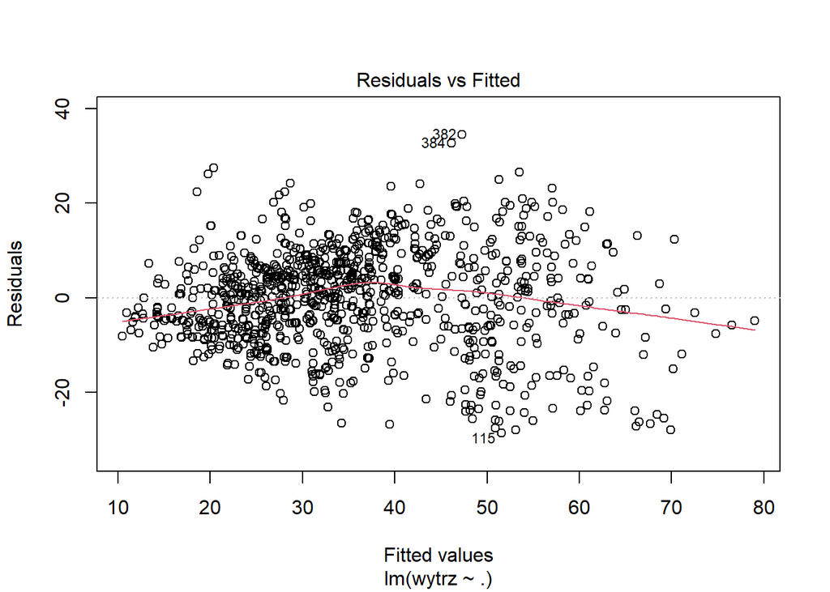

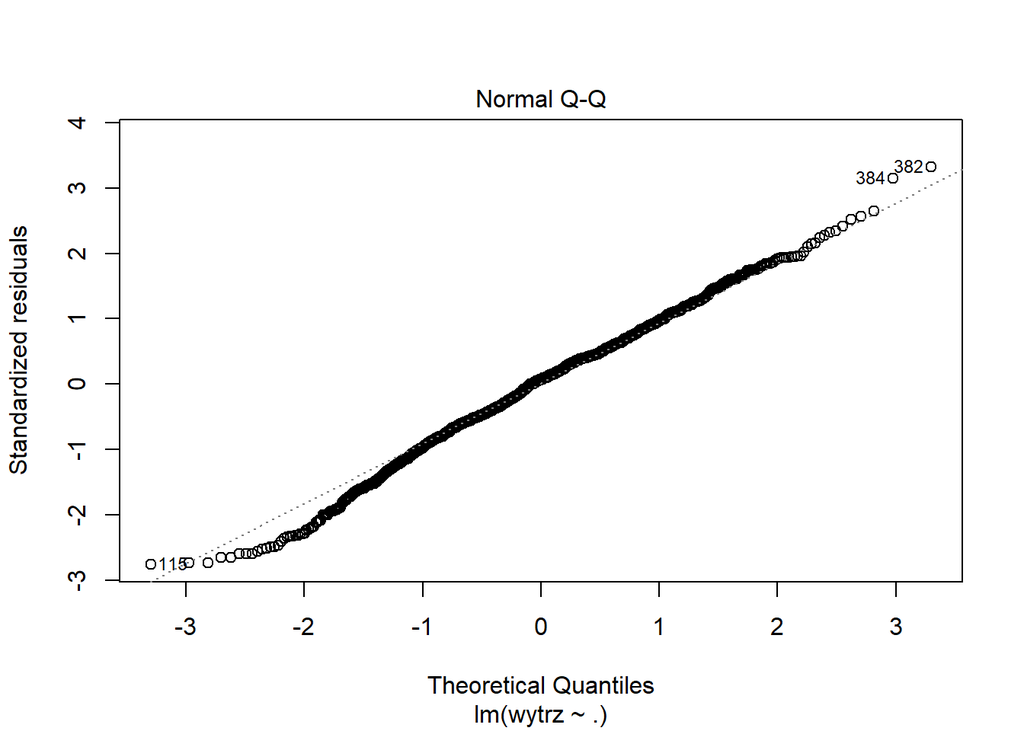

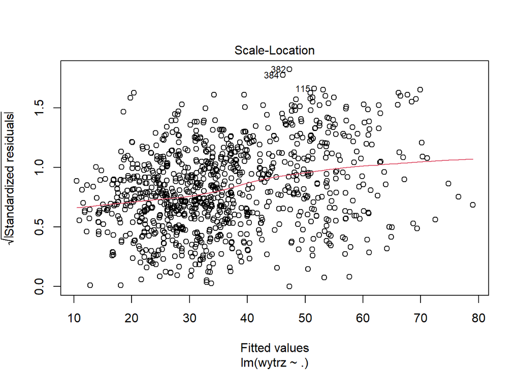

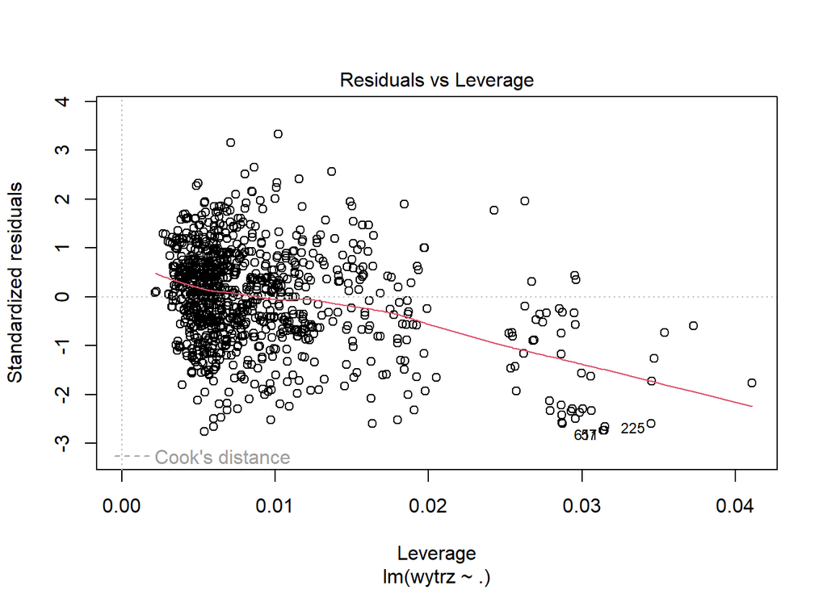

```r
plot(m2)
```

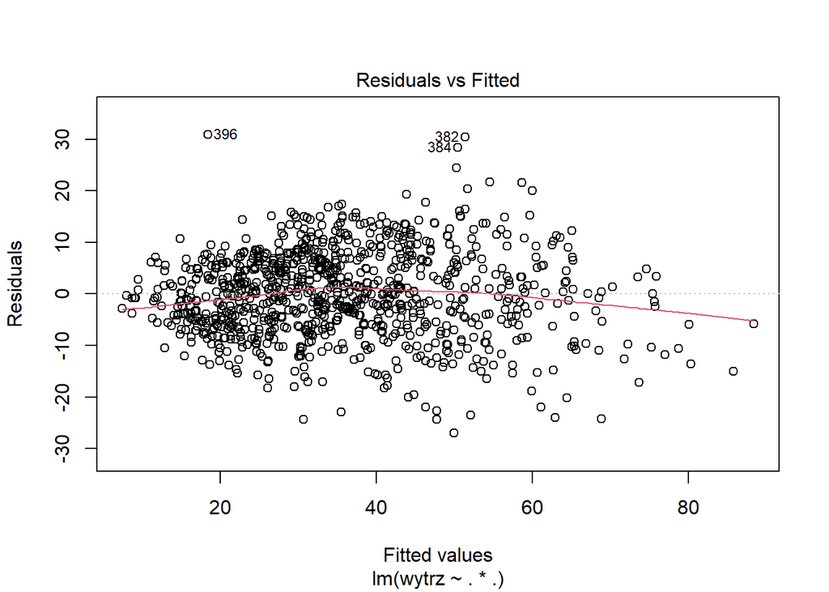

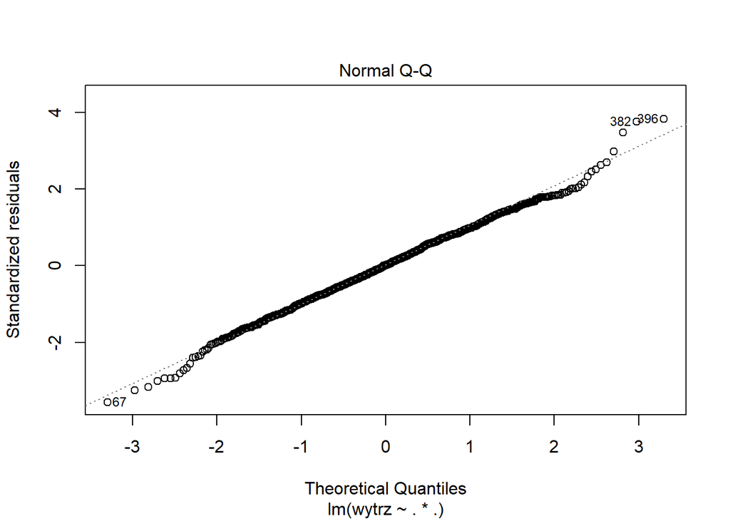

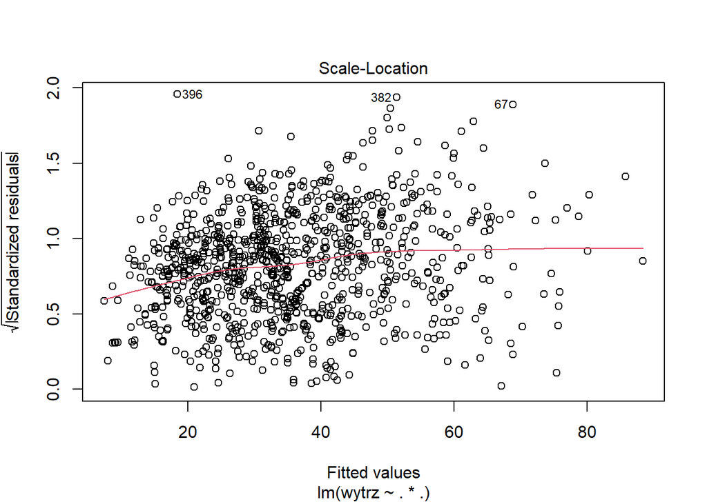

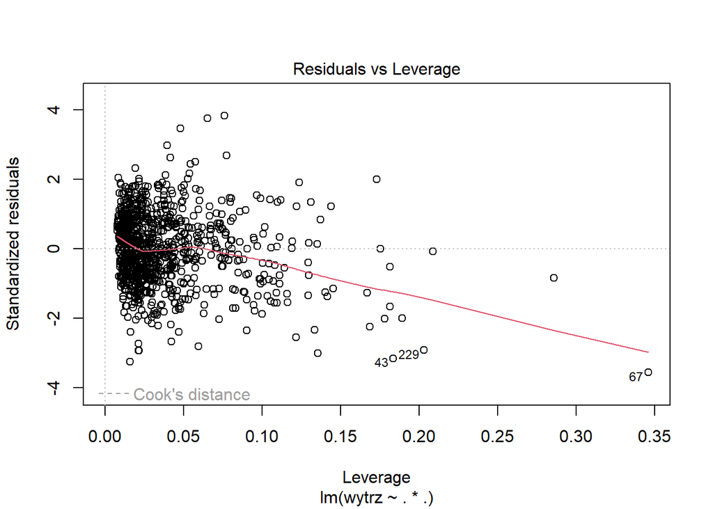

```r
plot(m3)
```

Z wykresów diagnostycznych można dowiedzieć się, że:

- W obu modelach reszty nie zależą funkcyjnie od zmiennej objaśnianej
- Na podstawie wykresu QQ można podejrzewać, że może wystąpić problem braku normalności rozkładu reszt modeli
- Obecność trendu na wykresach “Scale Location” sugeruje, że wariancja reszt nie będzie jednorodna, co świadczy o nie najlepszym dopasowaniu modeli.
- Na podstawie ostatniego wykresu można stwierdzić, że istnieją wartości o dużym udziale w modelu, ale nie można uznać ich za wartości odstające. Wartości, które znacznie odstają można by usunąć z modelu z założeniem, że i tak nie da się, korzystając z metod regresyjnych, dobrze prognozować wartości ekstremalnych

Obserwacje wynikające z wykresów można sprawdzić testami statystycznymi:

```r
# normalność reszt:
shapiro.test(m2$residuals)
```

```
##
##  Shapiro-Wilk normality test
##
## data:  m2$residuals
## W = 0.99532, p-value = 0.002986
```

```r
shapiro.test(m3$residuals)
```

```
##
##  Shapiro-Wilk normality test
##
## data:  m3$residuals
## W = 0.99704, p-value = 0.05278
```

```r
# jednorodnosc wariancj
bptest(m2)
```

```
##
##  studentized Breusch-Pagan test
##
## data:  m2
## BP = 137.17, df = 8, p-value < 2.2e-16
```

```r
bgtest(m3)
```

```
##
##  Breusch-Godfrey test for serial correlation of order up to 1
##
## data:  m3
## LM test = 96.029, df = 1, p-value < 2.2e-16
```

```r
# autokorelacja reszt:
dwtest(m2)
```

```
##
##  Durbin-Watson test
##
## data:  m2
## DW = 1.2815, p-value < 2.2e-16
## alternative hypothesis: true autocorrelation is greater than 0
```

```r
dwtest(m3)
```

```
##
##  Durbin-Watson test
##
## data:  m3
## DW = 1.4078, p-value < 2.2e-16
## alternative hypothesis: true autocorrelation is greater than 0
```

Żeby zdecydować się na wybór modelu, który jest wart dalszego dopracowywania, skorzystamy z globalnego testu z pakietu *hydroGOf*. Porównanie modeli:

```r
cbind(gof(predict(m2),dt$wytrz),gof(predict(m3),dt$wytrz))
```

```
##           [,1]  [,2]
## ME        0.00  0.00
## MAE       8.21  6.59
## MSE     107.21 67.83
## RMSE     10.35  8.24
## NRMSE %  62.00 49.30
## PBIAS %   0.00  0.00
## RSR       0.62  0.49
## rSD       0.78  0.87
## NSE       0.62  0.76
## mNSE      0.39  0.51
## rNSE     -0.19  0.15
## d         0.87  0.93
## md        0.66  0.74
## rd        0.60  0.74
## cp        0.56  0.72
## r         0.78  0.87
## R2        0.62  0.76
## bR2       0.57  0.72
## KGE       0.70  0.82
## VE        0.77  0.82
```

Na podstawie powyższej tabeli można zauważyć, że model m3 cechuje się mniejszymi średnimi błędami i lepszym dopasowaniem od modelu m2.

Do porównania tych modeli można użyć jeszcze kryterium Schwarza-Bayesa oraz kryterium Akaikego

```r
cbind(AIC(m2,m3)[2], BIC(m2,m3)[2])
```

```
##         AIC      BIC
## m2 7758.064 7807.437
## m3 7342.492 7530.110
```

m3 cechuje się lepszymi wynikami kryteriów oceny.